# Taller 3 - Minería de Datos

Predicción de ITU (Infección del Tracto Urinario) a partir de datos de utilización de servicios de salud

Keiner Felipe Correa Leguizamón

2026-07-10

# 1. Introducción y objetivo

Este trabajo desarrolla un análisis completo de minería de datos aplicado a una base real de utilización de servicios de salud, con el fin de identificar beneficiarios con **ITU (Infección del Tracto Urinario)**, entrenar y comparar modelos predictivos, interpretar los resultados y estimar el costo esperado asociado a la enfermedad.

**Enfermedad seleccionada:** ITU (Infección del Tracto Urinario) **Códigos CID utilizados:** N39.0 (ITU sitio no especificado), N30 (cistitis), N10 (pielonefritis aguda), N11 (nefritis túbulo-intersticial crónica), N12 (nefritis no especificada aguda o crónica).

Fuente de referencia para los códigos: OMS, ICD-10 Browser (https://icd.who.int/browse10/2019/en).

Todo el código reproducible está en `taller_3.R`

```r
variables_beneficiario <- readRDS("data/variables_beneficiario.rds")
resultados_modelos     <- readRDS("data/resultados_modelos.rds")
modelo_costo           <- readRDS("data/modelo_costo.rds")
io                      <- readRDS("data/informe_objetos.rds")
```

# 2. Calidad de datos

La base presentó un 88.6% de valores faltantes en `CID`, lo que llevó a una decisión metodológica clave: la variable objetivo `itu` se construyó exclusivamente a partir de las transacciones con `CID` no faltante, pero las variables predictoras a nivel de beneficiario se calcularon sobre la base completa, para no subestimar la utilización y el costo real de cada paciente. Otras variables con alto porcentaje de faltantes son `DESC_ESPECIALIDADE` (73.2%), `PORTE_ANESTESICO` (45.0%), y `TIPO_UNIDADE_PREST_HOSPITALAR` / `UF_CNES_PREST_HOSPITALAR` (28.8% cada una).

Otros problemas identificados y su tratamiento:

- **Sexo inconsistente:** 525 beneficiarios con más de un valor de `SEXO_BENEFICIARIO` en distintas transacciones — se resolvió con la moda (el valor más frecuente) por beneficiario.
- **Fechas inválidas:** 31.178 registros con `DT_UTILIZACAO` anterior a `DT_NASCIMENTO_BENEFICIARIO` o fechas futuras (31173 del primer tipo, 5 del segundo) — se marcaron como `NA` en vez de eliminar la fila completa, para no perder el resto de la información del registro.
- **Valores de `VALOR_UTILIZACAO` ≤ 0:** 73.395 registros — se recodificaron como `NA` (un costo de utilización no puede ser negativo o cero) antes de aplicar la transformación logarítmica.
- **Valores extremos:** detectados con criterio IQR sobre `log(VALOR_UTILIZACAO)` (la variable tiene cola pesada), con un umbral de $189.971. Se marcaron (variable `es_valor_extremo`), no se eliminaron, para permitir su uso como señal en el modelamiento.
- **Categorías con muchos faltantes** (`PORTE_ANESTESICO`, `UF_CNES_PREST_HOSPITALAR`, `TIPO_UNIDADE_PREST_HOSPITALAR`): imputadas con una categoría explícita (“No_aplica” / “Desconocido”) en vez de eliminarse, para no perder información de las demás variables del registro.
- **Edades fuera de rango (< 0 o > 110 años):** 514 beneficiarios, recodificados como `NA` e imputados con la mediana en la tabla de modelamiento.

Tras la limpieza, la base contiene 9.345.278 transacciones correspondientes a 653.631 beneficiarios únicos.

```r
io$na_summary %>%
  slice_max(pct_na, n = 10) %>%
  knitr::kable(col.names = c("Variable", "N° NA", "% NA"))
```

| Variable | N° NA | % NA |
| --- | --- | --- |
| CID | 8282833 | 88.63 |
| DESC_ESPECIALIDADE | 6841439 | 73.21 |
| PORTE_ANESTESICO | 4202557 | 44.97 |
| TIPO_UNIDADE_PREST_HOSPITALAR | 2686301 | 28.75 |
| UF_CNES_PREST_HOSPITALAR | 2686301 | 28.75 |
| DT_NASCIMENTO_BENEFICIARIO | 1940 | 0.02 |
| UTI | 0 | 0.00 |
| INTERNADO | 0 | 0.00 |
| DT_UTILIZACAO | 0 | 0.00 |
| TIPO_BENEFICIARIO | 0 | 0.00 |
| SEXO_BENEFICIARIO | 0 | 0.00 |
| CETIPO | 0 | 0.00 |
| CD_PROCEDIMENTO | 0 | 0.00 |
| DESCRICAO_PROCEDIMENTO | 0 | 0.00 |
| VALOR_UTILIZACAO | 0 | 0.00 |
| CHAVE_FUNCIONAL | 0 | 0.00 |

# 3. Construcción de la variable objetivo

La variable objetivo `itu` se construyó a nivel de `CHAVE_FUNCIONAL`: un beneficiario recibe la etiqueta 1 si tiene al menos una transacción con un código CID en el conjunto `{N39.0, N30, N10, N11, N12}`, y 0 en caso contrario.

```r
io$cid_codigos_itu %>%
  knitr::kable(col.names = c("Código CID", "N° transacciones"),
               caption = "Códigos de ITU encontrados en la base (sobre transacciones con CID no faltante)")
```

Códigos de ITU encontrados en la base (sobre transacciones con CID no faltante)

| Código CID | N° transacciones |
| --- | --- |
| N390 | 28847 |
| N110 | 3152 |
| N300 | 1215 |
| N10 | 792 |
| N111 | 524 |
| N308 | 469 |
| N304 | 271 |
| N309 | 109 |
| N30 | 49 |
| N12 | 11 |
| N11 | 3 |

El código más frecuente es, con amplio margen, `N390` (ITU de sitio no especificado), consistente con lo esperado en un diagnóstico registrado en atención primaria/urgencias sin mayor precisión etiológica.

```r
variables_beneficiario %>%
  count(itu) %>%
  mutate(pct = round(100 * n / sum(n), 3)) %>%
  knitr::kable(col.names = c("ITU", "N° beneficiarios", "%"))
```

| ITU | N° beneficiarios | % |
| --- | --- | --- |
| 0 | 653212 | 99.936 |
| 1 | 419 | 0.064 |

La prevalencia observada es extremadamente baja (**0.064%**, 419 beneficiarios de 653.631), lo que condicionó fuertemente la elección de métricas de evaluación en la sección de modelamiento: con esta prevalencia, un modelo sin ningún poder predictivo tendría un PR-AUC de referencia (piso) de aproximadamente **6.4^{-4}**.

# 4. Construcción de variables y análisis descriptivo

Las variables a nivel de beneficiario incluyen conteos de procedimientos, utilizaciones y especialidades, proporciones de internación y urgencias, costo total y promedio (con transformación logarítmica), edad, sexo, tipo de beneficiario, y dos señales específicas de la enfermedad seleccionada: `tuvo_urologia` (visita a urología/nefrología) y `tuvo_examen_orina` (procedimiento relacionado con urocultura/urinálisis).

Se analizaron **653.631 beneficiarios**, que en conjunto registran **2.250.299 utilizaciones** (fechas únicas de atención) y **9.345.278 procedimientos**.

**Perfil por sexo y tipo de beneficiario.** La proporción de ITU es algo mayor en mujeres 0.07% vs. 0.06% en hombres y en el grupo “Titular” frente a “Dependiente”, aunque las diferencias son pequeñas dado el tamaño reducido de la clase positiva:

```r
variables_beneficiario %>%
  count(SEXO_BENEFICIARIO, itu) %>%
  group_by(SEXO_BENEFICIARIO) %>%
  mutate(pct = round(100 * n / sum(n), 3)) %>%
  knitr::kable(col.names = c("Sexo", "ITU", "N", "%"))
```

| Sexo | ITU | N | % |
| --- | --- | --- | --- |
| F | 0 | 359642 | 99.930 |
| F | 1 | 253 | 0.070 |
| M | 0 | 263204 | 99.945 |
| M | 1 | 146 | 0.055 |
| SIN INFORMACION | 0 | 30366 | 99.934 |
| SIN INFORMACION | 1 | 20 | 0.066 |

```r
variables_beneficiario %>%
  count(tipo_beneficiario_grp, itu) %>%
  group_by(tipo_beneficiario_grp) %>%
  mutate(pct = round(100 * n / sum(n), 3)) %>%
  knitr::kable(col.names = c("Tipo de beneficiario", "ITU", "N", "%"))
```

| Tipo de beneficiario | ITU | N | % |
| --- | --- | --- | --- |
| DEPENDIENTE | 0 | 273193 | 99.952 |
| DEPENDIENTE | 1 | 130 | 0.048 |
| OTROS | 0 | 10746 | 99.916 |
| OTROS | 1 | 9 | 0.084 |
| SIN INFORMACION | 0 | 30736 | 99.935 |
| SIN INFORMACION | 1 | 20 | 0.065 |
| TITULAR | 0 | 338537 | 99.923 |
| TITULAR | 1 | 260 | 0.077 |

El hallazgo descriptivo más claro es la diferencia de edad, uso de servicios y costo entre ambos grupos. Los beneficiarios con ITU son en promedio 20 años mayores, usan muchos más servicios y cuestan, en promedio, cerca de 17 veces más que el resto:

```r
variables_beneficiario %>%
  group_by(itu) %>%
  summarise(
    edad_media   = round(mean(edad, na.rm = TRUE), 1),
    procedimientos_media = round(mean(n_procedimientos), 1),
    costo_medio  = round(mean(costo_total), 0)
  ) %>%
  knitr::kable(col.names = c("ITU", "Edad media", "Procedimientos (media)", "Costo total medio ($)"))
```

| ITU | Edad media | Procedimientos (media) | Costo total medio ($) |
| --- | --- | --- | --- |
| 0 | 38.3 | 14.2 | 1513 |
| 1 | 58.6 | 175.6 | 25081 |

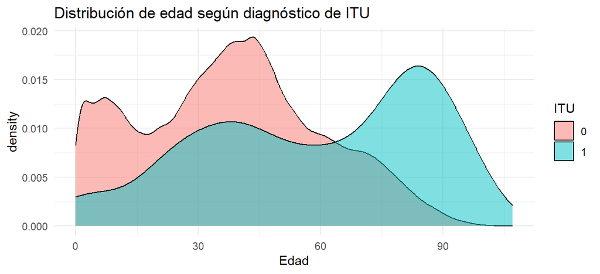

```r
ggplot(variables_beneficiario, aes(x = edad, fill = factor(itu))) +
  geom_density(alpha = 0.5) +
  labs(title = "Distribución de edad según diagnóstico de ITU",
       x = "Edad", fill = "ITU") +
  theme_minimal()
```

**Distribución por estado/región del prestador hospitalario.** La variable `UF_CNES_PREST_HOSPITALAR` identifica el estado donde se ubica el prestador (28.8% de las transacciones originales no tenían esta información, imputada como “Desconocido”). Entre los beneficiarios con ITU, la distribución por estado no muestra una concentración geográfica marcada distinta a la del resto de la población — consistente con que la ITU es una condición común y no asociada a un factor regional específico:

```r
io$estado_itu %>%
  knitr::kable(col.names = c("Estado (UF)", "N° beneficiarios con ITU"),
               caption = "Estados con más beneficiarios con ITU (top 10)")
```

Estados con más beneficiarios con ITU (top 10)

| Estado (UF) | N° beneficiarios con ITU |
| --- | --- |
| SP | 333 |
| Desconocido | 283 |
| PR | 54 |
| RS | 28 |
| RJ | 16 |
| CE | 10 |
| SC | 7 |
| MG | 4 |
| DF | 3 |
| SE | 3 |

**Especialidades más consultadas por beneficiarios con ITU.** Sin contar los registros sin especialidad informada, predominan la atención de urgencias y medicina general/clínica — coherente con una enfermedad que suele diagnosticarse y tratarse en atención de urgencias o primaria, no en consulta especializada:

```r
io$top_especialidades_itu %>%
  filter(!is.na(DESC_ESPECIALIDADE)) %>%
  slice_head(n = 10) %>%
  knitr::kable(col.names = c("Especialidad", "N° transacciones"))
```

| Especialidad | N° transacciones |
| --- | --- |
| PRONTO ATENDIMENTO GERAL | 1587 |
| MEDICO CLINICO | 1525 |
| CLINICO GERAL | 902 |
| HOSPITAIS | 297 |
| MEDICO DE FAMILIA E COMUNIDADE | 168 |
| MEDICO GERIATRA | 127 |
| MEDICO CARDIOLOGISTA | 98 |
| MEDICO EM RADIOLOGIA E DIAGNOSTICO POR IMAGEM | 87 |
| ANALISES CLINICAS | 79 |
| MEDICO HEMATOLOGISTA | 73 |

# 5. Modelamiento predictivo

Se entrenaron y compararon cuatro modelos de clasificación: regresión logística ponderada, Random Forest (con muestreo estratificado), Gradient Boosting y XGBoost — todos compensando el desbalance de clases mediante pesos o muestreo, y evaluados sobre un conjunto de test que preserva la proporción real de la población (no balanceado artificialmente).

La partición fue **70% entrenamiento / 15% validación / 15% test** (457.543 / 98.045 / 98.043 beneficiarios). El peso asignado a la clase positiva en la logística y en XGBoost (`scale_pos_weight`) fue **1555.27**, el cociente entre negativos y positivos en entrenamiento. El umbral de decisión de cada modelo se optimizó por F1 sobre el conjunto de **validación**, y se aplicó después sobre test:

```r
io$umbrales %>%
  mutate(across(where(is.numeric), ~round(., 3))) %>%
  knitr::kable(col.names = c("Modelo", "Umbral óptimo (F1 en validación)", "F1 (validación)"))
```

| Modelo | Umbral óptimo (F1 en validación) | F1 (validación) |
| --- | --- | --- |
| logit | 0.90 | 0.060 |
| rf | 0.89 | 0.188 |
| gbm | 0.08 | 0.248 |
| xgb | 0.90 | 0.106 |

```r
resultados_modelos %>%
  arrange(desc(pr_auc)) %>%
  mutate(across(where(is.numeric), ~ round(., 3))) %>%
  knitr::kable()
```

| modelo | accuracy | f1 | sensibilidad | especificidad | roc_auc | pr_auc |
| --- | --- | --- | --- | --- | --- | --- |
| xgb | 0.993 | 0.105 | 0.694 | 0.993 | 0.991 | 0.089 |
| rf | 0.997 | 0.155 | 0.484 | 0.997 | 0.992 | 0.082 |
| gbm | 0.999 | 0.210 | 0.306 | 0.999 | 0.938 | 0.079 |
| logit | 0.983 | 0.055 | 0.790 | 0.983 | 0.981 | 0.043 |

**Métrica principal:** dada la prevalencia extrema (0.064%), la métrica principal es PR-AUC, comparada contra el piso teórico de un modelo sin poder predictivo (≈6.4^{-4}). El mejor modelo en PR-AUC es **XGBoost** (PR-AUC ≈ 0.089), que representa aproximadamente 139 veces ese piso — evidencia de que el modelo capta una señal real, aunque el valor absoluto de la métrica parezca bajo. El accuracy de todos los modelos supera 98% de forma casi trivial (basta con predecir “No” casi siempre), y debe interpretarse en relación con el piso teórico de PR-AUC en vez de en términos absolutos.

**Elección de modelo principal.** Random Forest tiene el mejor ROC-AUC (0.992) y un PR-AUC muy cercano al de XGBoost (0.082 vs. 0.089). Se selecciona Random Forest como modelo principal para la interpretación porque ofrece el mejor balance global sensibilidad/especificidad sin sacrificar tanto la especificidad como XGBoost. XGBoost se reporta como modelo de comparación: logra el PR-AUC más alto y una sensibilidad marcadamente mayor (0.69 vs. 0.48 de RF), un trade-off relevante si el objetivo de negocio prioriza detectar más casos reales de ITU sobre minimizar falsas alarmas. GBM, pese a tener el mejor F1 (0.210), es el modelo con menor sensibilidad de los tres modelos de árboles (0.31): su umbral óptimo resultó muy bajo (0.08), lo que sugiere que sus probabilidades predichas están poco calibradas para esta clase tan rara.

# 6. Interpretación de resultados

**Importancia de variables (Random Forest).** Las variables más influyentes son, en orden: `prop_internaciones`, `costo_log`, `tuvo_examen_orina`, `edad` y `rango_dias`:

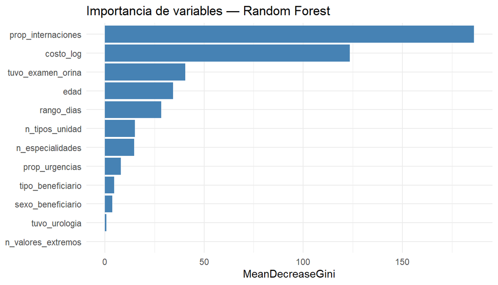

```r
io$importancia_rf %>%
  mutate(variable = fct_reorder(variable, MeanDecreaseGini)) %>%
  ggplot(aes(x = variable, y = MeanDecreaseGini)) +
  geom_col(fill = "steelblue") +
  coord_flip() +
  labs(title = "Importancia de variables — Random Forest",
       x = NULL, y = "MeanDecreaseGini") +
  theme_minimal()
```

Esto tiene sentido clínico: las formas más graves de ITU, como la pielonefritis (N10-N12), suelen requerir hospitalización, lo que explica el peso de `prop_internaciones` y `costo_log`. La edad es consistente con el perfil descriptivo en la sección 4 (58.6 vs. 38.3 años en promedio). Sin embargo, `tuvo_examen_orina` es una señal del proceso clínico, y `rango_dias` puede reflejar sesgo por tiempo de observación más que riesgo real.

Los odds ratios de la regresión logística apuntan en la misma dirección: `prop_internaciones` tiene el efecto más fuerte por lejos (OR ≈ 712), seguido de `tuvo_examen_orina` (OR ≈ 5.8) y `prop_urgencias` (OR ≈ 3.6):

```r
io$coef_logit %>%
  mutate(across(where(is.numeric), ~round(., 4))) %>%
  select(term, estimate, p.value) %>%
  knitr::kable(col.names = c("Variable", "Odds ratio", "p-valor"),
               caption = "Coeficientes de la logística (ordenados por magnitud del efecto)")
```

Coeficientes de la logística (ordenados por magnitud del efecto)

| Variable | Odds ratio | p-valor |
| --- | --- | --- |
| prop_internaciones | 711.7212 | 0.0000 |
| tuvo_examen_orina | 5.7753 | 0.0000 |
| prop_urgencias | 3.6081 | 0.0000 |
| tipo_beneficiarioOTROS | 3.3895 | 0.0000 |
| n_valores_extremos | 0.0000 | 0.5758 |
| (Intercept) | 0.0004 | 0.0000 |
| costo_log | 1.9772 | 0.0000 |
| tipo_beneficiarioTITULAR | 1.7539 | 0.0000 |
| sexo_beneficiarioM | 1.5857 | 0.0000 |
| tipo_beneficiarioSIN INFORMACION | 0.4453 | 0.0000 |
| tuvo_urologia | 0.4973 | 0.0000 |
| sexo_beneficiarioSIN INFORMACION | 1.1730 | 0.3439 |
| n_especialidades | 1.1387 | 0.0000 |
| n_tipos_unidad | 0.9677 | 0.0000 |
| rango_dias | 1.0121 | 0.0000 |
| edad | 0.9936 | 0.0000 |

**Comparación entre modelos.** El trade-off central es sensibilidad vs. especificidad: Random Forest y GBM son más conservadores (mayor especificidad, menor sensibilidad), mientras que XGBoost y la logística detectan más casos reales de ITU a costa de más falsos positivos. GBM, en particular, quedó con la sensibilidad más baja de los modelos de árboles (0.31) pese a la optimización de umbral en validación, lo que sugiere que su score no discrimina tan bien en la cola de probabilidades bajas donde vive la mayoría de los positivos reales.

**Análisis de errores (Random Forest, test).** Los falsos positivos son, en promedio, los beneficiarios de mayor edad de las tres categorías (64.8 años), más incluso que los verdaderos positivos; los falsos negativos son más jóvenes que los aciertos con ITU pero más viejos que el promedio general (47.3 años):

```r
io$test_con_pred_resumen %>%
  mutate(across(where(is.numeric), ~round(., 2))) %>%
  knitr::kable(col.names = c("Grupo", "N", "Edad media", "Costo medio ($)",
                             "Prop. internaciones", "% con examen de orina"))
```

| Grupo | N | Edad media | Costo medio ($) | Prop. internaciones | % con examen de orina |
| --- | --- | --- | --- | --- | --- |
| Correcto | 97717 | 38.25 | 1449.68 | 0.01 | 13.0 |
| Falso negativo | 32 | 47.28 | 19052.48 | 0.39 | 68.8 |
| Falso positivo | 294 | 64.76 | 30836.17 | 0.58 | 94.6 |

Esto sugiere que el modelo confunde ITU con “paciente mayor con hospitalización severa en general” comparte el perfil de edad y de internación con otras enfermedades graves, y probablemente detecta mejor los casos donde además hay una urocultura/urinálisis registrado (predictor que, como se discute abajo, es consecuencia de la sospecha clínica y no un factor de riesgo previo).

**Sesgos y limitaciones:**

- La variable objetivo depende del subregistro del CID: solo el 11.4% de las transacciones tienen CID informado, por lo que la prevalencia real de ITU es casi con certeza mayor a la observada (0.064%).
- `rango_dias` como variable importante sugiere sesgo por tiempo de observación: a más historial en la base, más oportunidad de que quede registrado un diagnóstico.
- `tuvo_examen_orina` es un predictor “río abajo” del proceso clínico (pedir una urocultura ya refleja sospecha médica de ITU), lo que puede limitar la generalización del modelo a contextos donde ese detalle no se registre.
- Se evaluó ROSE como estrategia adicional de balanceo, pero no resultó compatible con las variables categóricas del modelo sin trabajo adicional de codificación; se optó por mantener class weights y muestreo estratificado (sampsize/strata), técnicas estándar y más fáciles de justificar metodológicamente.

# 7. Estimación del costo asociado a ITU

El costo promedio por beneficiario es notablemente mayor en el grupo con ITU ($25.081 frente a $1.513 en el grupo sin ITU):

```r
io$costo_por_grupo %>%
  mutate(across(where(is.numeric), ~round(., 1))) %>%
  knitr::kable(col.names = c("ITU", "N", "Costo medio ($)", "Costo mediana ($)","Desv. estándar", "Percentil 90"))
```

[output not shown]

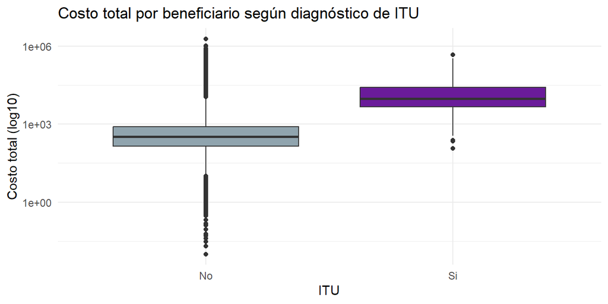

```r
variables_beneficiario %>%
  mutate(itu = factor(itu, levels = c(0, 1), labels = c("No", "Si"))) %>%
  ggplot(aes(x = itu, y = costo_total)) +
  geom_boxplot(fill = c("#90A4AE", "#6A1B9A")) +
  scale_y_log10() +
  labs(title = "Costo total por beneficiario según diagnóstico de ITU",
       x = "ITU", y = "Costo total (log10)") +
  theme_minimal()
```

Sin embargo, esta brecha se explica en gran parte por la mayor utilización de servicios (internaciones, urgencias, número de utilizaciones) del grupo con ITU, y no por un efecto independiente del diagnóstico en sí. Un modelo GLM Gamma (log-link) que controla por edad, sexo, tipo de beneficiario y variables de utilización muestra que, una vez controlado por esto, el coeficiente de `itu` deja de ser significativo (p ≈ 0.77) y su magnitud cae a prácticamente 1 (ligeramente por debajo):

```r
io$coef_costo %>%
  mutate(across(where(is.numeric), ~round(., 4))) %>%
  select(term, estimate, p.value) %>%
  knitr::kable(col.names = c("Variable", "Efecto multiplicativo", "p-valor"),
               caption = "Modelo de costo (GLM Gamma, log-link) — efectos controlando por utilización")
```

Modelo de costo (GLM Gamma, log-link) — efectos controlando por utilización

| Variable | Efecto multiplicativo | p-valor |
| --- | --- | --- |
| (Intercept) | 233.4946 | 0.0000 |
| n_internaciones | 2.2003 | 0.0000 |
| tipo_beneficiarioOTROS | 0.5334 | 0.0000 |
| sexo_beneficiarioSIN INFORMACION | 0.7495 | 0.0742 |
| n_utilizaciones | 1.2089 | 0.0000 |
| n_urgencias | 1.0711 | 0.0000 |
| tipo_beneficiarioSIN INFORMACION | 1.0698 | 0.6746 |
| ituSi | 0.9323 | 0.7656 |
| sexo_beneficiarioM | 1.0548 | 0.0000 |
| n_especialidades | 1.0172 | 0.0003 |
| tipo_beneficiarioTITULAR | 1.0147 | 0.2717 |
| edad | 1.0112 | 0.0000 |

En contraste, un modelo simple sin controlar por utilización (solo edad, sexo, tipo de beneficiario e ITU) sí muestra un efecto ITU enorme y significativo (11.3x el costo esperado, p < 0.001):

```r
io$efecto_itu_simple %>%
  mutate(across(where(is.numeric), ~round(., 3))) %>%
  select(term, estimate, conf.low, conf.high, p.value) %>%
  knitr::kable(col.names = c("Variable", "Efecto multiplicativo", "IC 95% inf.", "IC 95% sup.", "p-valor"))
```

| Variable | Efecto multiplicativo | IC 95% inf. | IC 95% sup. | p-valor |
| --- | --- | --- | --- | --- |
| ituSi | 11.263 | 6.595 | 21.599 | 0 |

**Interpretación:** el diagnóstico de ITU en sí mismo no encarece adicionalmente la atención una vez que se sabe cuántas internaciones, urgencias y utilizaciones tuvo el beneficiario — el costo elevado observado en la sección descriptiva refleja que los pacientes con ITU (sobre todo formas graves como pielonefritis) *usan más servicios*, y es ese mayor uso, no la etiqueta diagnóstica per se, lo que explica el costo. Esto es consistente con el hallazgo de la sección 6: el perfil predictor más fuerte para detectar ITU es también el perfil predictor más fuerte del costo (`prop_internaciones`, `n_internaciones`).

Los perfiles predichos bajo un beneficiario “tipo” (edad y demás variables en su mediana/moda) confirman esto — el costo esperado es prácticamente el mismo con y sin ITU:

```r
io$perfiles_itu %>%
  mutate(costo_esperado = round(costo_esperado, 2)) %>%
  knitr::kable(col.names = c("ITU", "Costo esperado ($)"))
```

| ITU | Costo esperado ($) |
| --- | --- |
| No | 528.47 |
| Si | 492.69 |

# 8. Conclusiones, limitaciones y trabajos futuros

**¿Qué tan bien se logró identificar a los beneficiarios asociados a ITU?** De forma moderada pero real: el mejor modelo (XGBoost) alcanza un PR-AUC ≈0.089, cerca de 139 veces el piso teórico de un modelo sin poder predictivo (≈6.4^{-4}). El ROC-AUC de todos los modelos es alto (>0.93), pero bajo una prevalencia tan extrema esta métrica es engañosamente optimista; el PR-AUC —bajo en términos absolutos, pero claramente por encima del piso— es la lectura correcta del desempeño real.

**¿Qué variables parecen estar más relacionadas con la enfermedad?** `prop_internaciones`, `costo_log`, `tuvo_examen_orina`, `edad` y `rango_dias` (sección 6). De estas, la edad es el único factor de riesgo claramente pre-existente; el resto son en gran medida reflejo del proceso de atención (internación, sospecha clínica) más que factores de riesgo previos.

**¿Qué tan confiable es el modelo construido?** Con solo 419 casos positivos sobre 653.631 beneficiarios, las métricas de test (especialmente sensibilidad y F1) tienen incertidumbre considerable: un puñado de casos mal o bien clasificados cambia las métricas de forma notoria. El modelo es razonablemente confiable para *priorizar* beneficiarios de mayor riesgo relativo, no para un diagnóstico individual definitivo.

**¿Qué limitaciones tiene la base de datos?** El subregistro de CID (88.6% de transacciones sin diagnóstico) implica que la etiqueta `itu` probablemente subestima la prevalencia real. La base cubre solo la utilización dentro del plan de salud analizado, y `rango_dias` sugiere un sesgo por tiempo de observación: quienes llevan más tiempo en la base tienen más oportunidad de que se registre un diagnóstico.

**¿Qué limitaciones tiene la estrategia de modelamiento utilizada?** La clase positiva extremadamente pequeña (419 casos) limita la robustez de las métricas de test y hace sensibles los resultados a la partición específica usada. ROSE no fue viable con las variables categóricas del modelo sin recodificación adicional, por lo que se usaron class weights y muestreo estratificado como alternativa estándar.

**¿Qué mejoras podrían realizarse en un trabajo futuro?** Validación cruzada estratificada para métricas más robustas y con intervalos de incertidumbre; incorporar variables de texto de `DESCRICAO_PROCEDIMENTO` (p. ej. vía NLP simple) como señal adicional menos dependiente del CID; y explorar una ventana temporal explícita (predecir ITU futura con historial pasado) para reducir el sesgo de `rango_dias` y la posible fuga de información de variables como `tuvo_examen_orina`.